# Lab 1: Intro to R

Fun Nikkat Afrin

2024-09-01

### Loading pacakges using library function.

```r
library(tidyverse)
library(openintro)
```

### Arbuthnot Data set:

```r
arbuthnot
```

```
## # A tibble: 82 × 3
##     year  boys girls
##    <int> <int> <int>
##  1  1629  5218  4683
##  2  1630  4858  4457
##  3  1631  4422  4102
##  4  1632  4994  4590
##  5  1633  5158  4839
##  6  1634  5035  4820
##  7  1635  5106  4928
##  8  1636  4917  4605
##  9  1637  4703  4457
## 10  1638  5359  4952
## # ℹ 72 more rows
```

## Exercise 1

1. What command would you use to extract just the counts of girls baptized?
- To know the counts of the girls baptized each year we use **`$`** sign to extract the particular column of the data set in this case the girls column and we can see the count of the girls in each year.
- To know the total count of the girls baptized we use **Sum()** function here along with the **$**.

```r
arbuthnot$girls
```

```
##  [1] 4683 4457 4102 4590 4839 4820 4928 4605 4457 4952 4784 5332 5200 4910 4617
## [16] 3997 3919 3395 3536 3181 2746 2722 2840 2908 2959 3179 3349 3382 3289 3013
## [31] 2781 3247 4107 4803 4881 5681 4858 4319 5322 5560 5829 5719 6061 6120 5822
## [46] 5738 5717 5847 6203 6033 6041 6299 6533 6744 7158 7127 7246 7119 7214 7101
## [61] 7167 7302 7392 7316 7483 6647 6713 7229 7767 7626 7452 7061 7514 7656 7683
## [76] 5738 7779 7417 7687 7623 7380 7288
```

```r
sum(arbuthnot$girls)
```

```
## [1] 453841
```

## Exercise 2

2. Is there an apparent trend in the number of girls baptized over the years? How would you describe it?

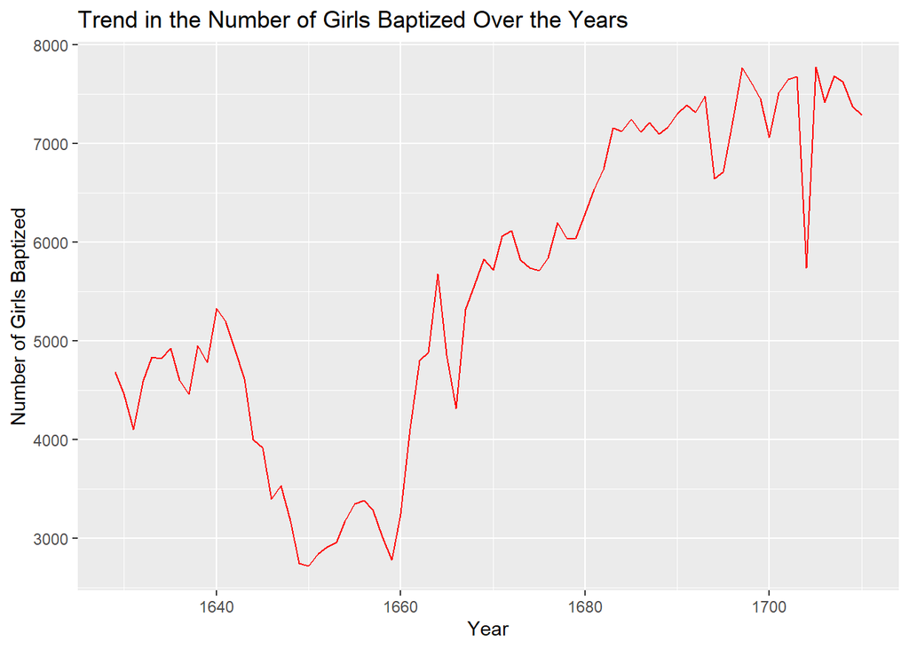

```r
ggplot(data = arbuthnot, aes(x = year, y = girls)) +
geom_line(color='red')+labs(title = "Trend in the Number of Girls Baptized Over the Years",
       x = "Year",
       y = "Number of Girls Baptized")
```